# 10-non-parametric-tests

## Non-parametric tests

**Non-Parametric tests** do not require the sampling distribution to be normally distributed (a.k.a. “assumption free tests”). These tests may be used when the variable of interest is measured on an ordinal scale or when the parametric assumptions do not hold. They often rely on ranking the data instead of analyzing the actual scores. By ranking the data, information on the magnitude of differences is lost. Thus, parametric tests are more powerful if the sampling distribution is normally distributed.

When should you use non-parametric tests?

- When your DV is measured on an ordinal scale
- When your data is better represented by the median (e.g., there are outliers that you can’t remove)
- When the assumptions of parametric tests are not met (e.g., normally distributed sampling distribution)
- You have a very small sample size (i.e., the central limit theorem does not apply)

### Mann-Whitney U Test (a.k.a. Wilcoxon rank-sum test)

The Mann-Whitney U test is a non-parametric test of differences between groups, similar to the two sample t-test. In contrast to the two sample t-test it only requires ordinally scaled data and relies on weaker assumptions. Thus it is often useful if the assumptions of the t-test are violated, especially if the data is not on a ratio scale. The following assumptions must be fulfilled for the test to be applicable:

- The dependent variable is at least ordinally scaled (i.e. a ranking between values can be established)
- The independent variable has only two levels
- A between-subjects design is used (i.e., the subjects are not matched across conditions)

Intuitively, the test compares the frequency of low and high ranks between groups. Under the null hypothesis, the amount of high and low ranks should be roughly equal in the two groups. This is achieved through comparing the expected sum of ranks to the actual sum of ranks.

As an example, we will be using data obtained from a field experiment with random assignment. In a music download store, new releases were randomly assigned to an experimental group and sold at a reduced price (i.e., 7.95€), or a control group and sold at the standard price (9.95€). A representative sample of 102 new releases were sampled and these albums were randomly assinged to the experimental groups (i.e., 51 albums per group). The sales were tracked over one day.

Let’s load and investigate the data first:

```r
library(psych)
library(ggplot2)
rm(music_sales)
music_sales <- read.table("https://raw.githubusercontent.com/IMSMWU/Teaching/master/MRDA2017/music_experiment.dat",
                          sep = "\t",
                          header = TRUE) #read in data
music_sales$group <- factor(music_sales$group, levels = c(1:2), labels = c("low_price", "high_price")) #convert grouping variable to factor
str(music_sales) #inspect data
```

```
'data.frame':   102 obs. of  3 variables:
 $ product_id: int  1 2 3 4 5 6 7 8 9 10 ...
 $ unit_sales: int  6 27 30 24 21 11 18 15 18 13 ...
 $ group     : Factor w/ 2 levels "low_price","high_price": 1 1 1 1 1 1 1 1 1 1 ...
```

```r
head(music_sales) #inspect data
```

|  | product_id | unit_sales | group |
| --- | --- | --- | --- |
| 1 | 1 | 6 | low_price |
| 2 | 2 | 27 | low_price |
| 3 | 3 | 30 | low_price |
| 4 | 4 | 24 | low_price |
| 5 | 5 | 21 | low_price |
| 6 | 6 | 11 | low_price |

Inspect descriptives (overall and by group).

```r
psych::describe(music_sales$unit_sales) #overall descriptives
```

```
   vars   n mean   sd median trimmed  mad min max range skew kurtosis   se
X1    1 102 7.12 6.26      6     6.1 4.45   0  30    30 1.71     3.02 0.62
```

```r
describeBy(music_sales$unit_sales, music_sales$group) #descriptives by group
```

```
 Descriptive statistics by group
group: low_price
   vars  n mean   sd median trimmed  mad min max range skew kurtosis  se
X1    1 51 8.37 6.44      6    7.17 4.45   2  30    28 1.66     2.22 0.9
---------------------------------------------------------------------------------------------------------------------------------
group: high_price
   vars  n mean   sd median trimmed  mad min max range skew kurtosis   se
X1    1 51 5.86 5.87      3     4.9 4.45   0  30    30 1.84      4.1 0.82
```

Create boxplot and plot of means.

```r
ggplot(music_sales, aes(group, unit_sales)) +
  geom_bar(stat = "summary",  color = "black", fill = "white", width = 0.7) +
  geom_pointrange(stat = "summary") +
  labs(x = "Group", y = "Average number of sales") +
  theme_bw()
```

[output not shown]

```r
wilcox.test(unit_sales ~ group, data = music_sales) #Mann-Whitney U Test
```

```
    Wilcoxon rank sum test with continuity correction

data:  unit_sales by group
W = 1710, p-value = 0.005374
alternative hypothesis: true location shift is not equal to 0
```

### Wilcoxon signed-rank test

The Wilcoxon signed-rank test is a non-parametric test used to analyze the difference between paired observations, analogously to the paired t-test. It can be used when measurements come from the same observational units but the distributional assumptions of the paired t-test do not hold, because it does not require any assumptions about the distribution of the measurements. Since we subtract two values, however, the test requires that the dependent variable is at least interval scaled, meaning that intervals have the same meaning for different points on our measurement scale.

Under the null hypothesis $H_0$, the differences of the measurements should follow a symmetric distribution around 0, meaning that, on average, there is no difference between the two matched samples. $H_1$ states that the distributions mean is non-zero.

As an example, let’s consider a slightly different experimental setup for the music download store. Imagine that new releases were either sold at a reduced price (i.e., 7.95€), or at the standard price (9.95€). Every time a customer came to the store, the prices were randomly determined for every new release. This means that the same 51 albums were either sold at the standard price or at the reduced price and this price was determined randomly. The sales were then recorded over one day. Note the difference to the previous case, where we randomly split the sample and assigned 50% of products to each condition. Now, we randomly vary prices for all albums between high and low prices.

Let’s load and investigate the data first:

```r
rm(music_sales_dep)
music_sales_dep <- read.table("https://raw.githubusercontent.com/IMSMWU/Teaching/master/MRDA2017/music_experiment_dependent.dat",
                              sep = "\t",
                              header = TRUE) #read in data
str(music_sales_dep) #inspect data
```

```
'data.frame':   51 obs. of  3 variables:
 $ product_id           : int  1 2 3 4 5 6 7 8 9 10 ...
 $ unit_sales_low_price : int  6 27 30 24 21 11 18 15 18 13 ...
 $ unit_sales_high_price: int  9 12 30 18 20 15 2 3 3 9 ...
```

```r
head(music_sales_dep) #inspect data
```

|  | product_id | unit_sales_low_price | unit_sales_high_price |
| --- | --- | --- | --- |
| 1 | 1 | 6 | 9 |
| 2 | 2 | 27 | 12 |
| 3 | 3 | 30 | 30 |
| 4 | 4 | 24 | 18 |
| 5 | 5 | 21 | 20 |
| 6 | 6 | 11 | 15 |

Again, let’s assume that one of the prarametric assumptions has been violated and we needed to conduct a non-parametric test. Then the Wilcoxon signed-rank test can be performed with the same command as the Mann-Whitney U test, provided that the argument `paired` is set to `TRUE`.

```r
wilcox.test(music_sales_dep$unit_sales_low_price, music_sales_dep$unit_sales_high_price, paired = TRUE) #Wilcoxon signed-rank test
```

```
    Wilcoxon signed rank test with continuity correction

data:  music_sales_dep$unit_sales_low_price and music_sales_dep$unit_sales_high_price
V = 867.5, p-value = 0.004024
alternative hypothesis: true location shift is not equal to 0
```

Using the 95% confidence level, the result would suggest a significant effect of price on sales (i.e., p < 0.05).

### Kruskal-Wallis test

When should you use non-parametric tests?

- When the dependent variable is measured at an ordinal scale and we want to compare more than 2 means
- When the assumptions of independent ANOVA are not met (e.g., assumptions regarding the sampling distribution in small samples)

The Kruskal–Wallis test is the non-parametric counterpart of the one-way independent ANOVA. It is designed to test for significant differences in population medians when you have more than two samples (otherwise you would use the Mann-Whitney U-test). The theory is very similar to that of the Mann–Whitney U-test since it is also based on ranked data. The Kruskal-Wallis test is carried out using the `kruskal.test()` function. Using the same data as before, we type:

```r
kruskal.test(Sales ~ Promotion, data = online_store_promo)
```

[output not shown]

The test-statistic follows a chi-square distribution and since the test is significant (p < 0.05), we can conclude that there are significant differences in population medians. Provided that the overall effect is significant, you may perform a post hoc test to find out which groups are different. To get a first impression, we can plot the data using a boxplot:

```r
#Boxplot
ggplot(online_store_promo, aes(x = Promotion, y = Sales)) +
  geom_boxplot() +
  labs(x = "Experimental group (promotion level)", y = "Number of sales") +
  theme_bw()
```

[output not shown]

To test for differences between groups, we can, for example, apply post hoc tests according to Nemenyi for pairwise multiple comparisons of the ranked data using the appropriate function from the `PMCMR` package.

```r
library(PMCMR)
posthoc.kruskal.nemenyi.test(x = online_store_promo$Sales, g = online_store_promo$Promotion, dist = "Tukey")
```

[output not shown]

## Categorical data

In some instances, you will be confronted with differences between proportions, rather than differences between means. For example, you may conduct an A/B-Test and wish to compare the conversion rates between two advertising campaigns. In this case, your data is binary (0 = no conversion, 1 = conversion) and the sampling distribution for such data is binomial. While binomial probabilities are difficult to calculate, we can use a Normal approximation to the binomial when `n` is large (>100) and the true likelihood of a 1 is not too close to 0 or 1.

Let’s use an example: assume a call center where service agents call potential customers to sell a product. We consider two call center agents:

- Service agent 1 talks to 300 customers and gets 200 of them to buy (conversion rate=2/3)
- Service agent 2 talks to 300 customers and gets 100 of them to buy (conversion rate=1/3)

As always, we load the data first:

```r
call_center <- read.table("https://raw.githubusercontent.com/IMSMWU/Teaching/master/MRDA2017/call_center.dat",
                          sep = "\t",
                          header = TRUE) #read in data
call_center$conversion <- factor(call_center$conversion , levels = c(0:1), labels = c("no", "yes")) #convert to factor
call_center$agent <- factor(call_center$agent , levels = c(0:1), labels = c("agent_1", "agent_2")) #convert to factor
```

Next, we create a table to check the relative frequencies:

```r
rel_freq_table <- as.data.frame(prop.table(table(call_center), 2)) #conditional relative frequencies
rel_freq_table
```

[output not shown]

We could also plot the data to visualize the frequencies using ggplot:

```r
ggplot(rel_freq_table, aes(x = agent, y = Freq, fill = conversion)) + #plot data
  geom_col(width = .7) + #position
  geom_text(aes(label = paste0(round(Freq*100,0),"%")), position = position_stack(vjust = 0.5), size = 4) + #add percentages
  ylab("Proportion of conversions") + xlab("Agent") + # specify axis labels
  theme_bw()
```

[output not shown]

… or using the `mosaicplot()` function:

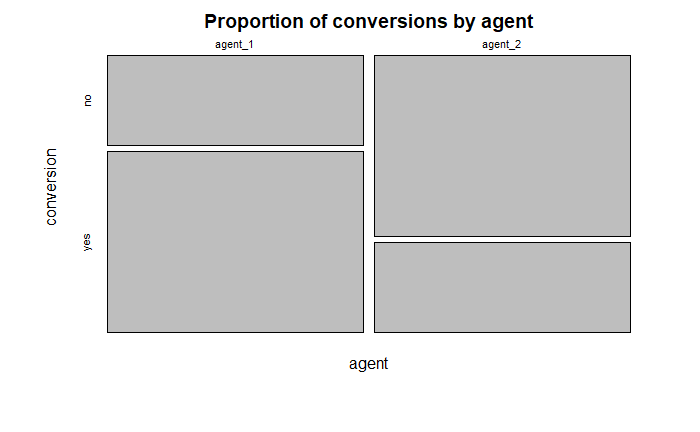

```r
contigency_table <- table(call_center)
mosaicplot(contigency_table, main = "Proportion of conversions by agent")
```

### Confidence intervals for proportions

Recall that we can use confidence intervals to determine the range of values that the true population parameter will take with a certain level of confidence based on the sample. Similar to the confidence interval for means, we can compute a confidence interval for proportions. The (1-$\alpha$)% confidence interval for proportions is approximately

$$CI = p\pm z_{1-\frac{\alpha}{2}}*\sqrt{\frac{p*(1-p)}{N}}$$

where $\sqrt{p(1-p)}$ is the equivalent to the standard deviation in the formula for the confidence interval for means. Based on the equation, it is easy to compute the confidence intervals for the conversion rates of the call center agents:

```r
n1 <- nrow(subset(call_center,agent=="agent_1")) #number of observations for agent 1
n2 <- nrow(subset(call_center,agent=="agent_2")) #number of observations for agent 1
n1_conv <- nrow(subset(call_center,agent=="agent_1" & conversion=="yes")) #number of conversions for agent 1
n2_conv <- nrow(subset(call_center,agent=="agent_2" & conversion=="yes")) #number of conversions for agent 2
p1 <- n1_conv/n1  #proportion of conversions for agent 1
p2 <- n2_conv/n2  #proportion of conversions for agent 2

error1 <- qnorm(0.975)*sqrt((p1*(1-p1))/n1)
ci_lower1 <- p1 - error1
ci_upper1 <- p1 + error1
ci_lower1
ci_upper1

error2 <- qnorm(0.975)*sqrt((p2*(1-p2))/n2)
ci_lower2 <- p2 - error2
ci_upper2 <- p2 + error2
ci_lower2
ci_upper2
```

[output not shown]

Similar to testing for differences in means, we could also ask: Is agent 1 twice as likely as agent 2 to convert a customer? Or, to state it formally:

$$H_0: \pi_1=\pi_2 \\
H_1: \pi_1\ne \pi_2$$

where $\pi$ denotes the population parameter associated with the proportion in the respective population. One approach to test this is based on confidence intervals to estimate the difference between two populations. We can compute an approximate confidence interval for the difference between the proportion of successes in group 1 and group 2, as:

$$CI = p_1-p_2\pm z_{1-\frac{\alpha}{2}}*\sqrt{\frac{p_1*(1-p_1)}{n_1}+\frac{p_2*(1-p_2)}{n_2}}$$

If the confidence interval includes zero, then the data does not suggest a difference between the groups. Let’s compute the confidence interval for differences in the proportions by hand first:

```r
ci_lower <- p1 - p2 - qnorm(0.975)*sqrt(p1*(1 - p1)/n1 + p2*(1 - p2)/n2) #95% CI lower bound
ci_upper <- p1 - p2 + qnorm(0.975)*sqrt(p1*(1 - p1)/n1 + p2*(1 - p2)/n2) #95% CI upper bound
ci_lower
ci_upper
```

[output not shown]

Now we can see that the 95% confidence interval estimate of the difference between the proportion of conversions for agent 1 and the proportion of conversions for agent 2 is between 26% and 41%. This interval tells us the range of plausible values for the difference between the two population proportions. According to this interval, zero is not a plausible value for the difference (i.e., interval does not cross zero), so we reject the null hypothesis that the population proportions are the same.

Instead of computing the intervals by hand, we could also use the `prop.test()` function:

```r
prop.test(x = c(n1_conv, n2_conv), n = c(n1, n2), conf.level = 0.95)
```

[output not shown]

Note that the `prop.test()` function uses a slightly different (more accurate) way to compute the confidence interval (Wilson’s score method is used). It is particularly a better approximation for smaller N. That’s why the confidence interval in the output slightly deviates from the manual computation above, which uses the Wald interval.

### Chi-square test

In the previous section, we saw how we can compute the confidence interval for the difference between proportions to decide on whether or not to reject the null hypothesis. Whenever you would like to investigate the relationship between two categorical variables, the $\chi^2$ test may be used to test whether the variables are independent of each other. It achieves this by comparing the expected number of observations in a group to the actual values. Let’s continue with the example from the previous section. Under the null hypothesis, the two variables *agent* and *conversion* in our contingency table are independent (i.e., there is no relationship). This means that the frequency in each field will be roughly proportional to the probability of an observation being in that category, calculated under the assumption that they are independent. The difference between that expected quantity and the actual quantity can be used to construct the test statistic. The test statistic is computed as follows:

$$\chi^2=\sum_{i=1}^{J}\frac{(f_o-f_e)^2}{f_e}$$

where $J$ is the number of cells in the contingency table, $f_o$ are the observed cell frequencies and $f_e$ are the expected cell frequencies. The larger the differences, the larger the test statistic and the smaller the p-value.

The observed cell frequencies can easily be seen from the contingency table:

```r
obs_cell1 <- contigency_table[1,1]
obs_cell2 <- contigency_table[1,2]
obs_cell3 <- contigency_table[2,1]
obs_cell4 <- contigency_table[2,2]
```

The expected cell frequencies can be calculated as follows:

$$f_e=\frac{(n_r*n_c)}{n}$$

where $n_r$ are the total observed frequencies per row, $n_c$ are the total observed frequencies per column, and $n$ is the total number of observations. Thus, the expected cell frequencies under the assumption of independence can be calculated as:

```r
n <- nrow(call_center)
exp_cell1 <- (nrow(call_center[call_center$agent=="agent_1",])*nrow(call_center[call_center$conversion=="no",]))/n
exp_cell2 <- (nrow(call_center[call_center$agent=="agent_1",])*nrow(call_center[call_center$conversion=="yes",]))/n
exp_cell3 <- (nrow(call_center[call_center$agent=="agent_2",])*nrow(call_center[call_center$conversion=="no",]))/n
exp_cell4 <- (nrow(call_center[call_center$agent=="agent_2",])*nrow(call_center[call_center$conversion=="yes",]))/n
```

To sum up, these are the expected cell frequencies

```r
data.frame(conversion_no = rbind(exp_cell1,exp_cell3),conversion_yes = rbind(exp_cell2,exp_cell4), row.names = c("agent_1","agent_2"))
```

[output not shown]

… and these are the observed cell frequencies

```r
data.frame(conversion_no = rbind(obs_cell1,obs_cell2),conversion_yes = rbind(obs_cell3,obs_cell4), row.names = c("agent_1","agent_2"))
```

[output not shown]

To obtain the test statistic, we simply plug the values into the formula:

```r
chisq_cal <-  sum(((obs_cell1 - exp_cell1)^2/exp_cell1),
                  ((obs_cell2 - exp_cell2)^2/exp_cell2),
                  ((obs_cell3 - exp_cell3)^2/exp_cell3),
                  ((obs_cell4 - exp_cell4)^2/exp_cell4))
chisq_cal
```

```
[1] 66.66667
```

$$df=(r-1)*(c-1)$$

where $r$ is the number of rows and $c$ is the number of columns in the contingency table. Recall that degrees of freedom are generally the number of values that can vary freely when calculating a statistic. In a 2 by 2 table as in our case, we have 2 variables (or two samples) with 2 levels and in each one we have 1 that vary freely. Hence, in our example the degrees of freedom can be calculated as:

```r
df <-  (nrow(contigency_table) - 1) * (ncol(contigency_table) -1)
df
```

```
[1] 1
```

Now, we can derive the critical value given the degrees of freedom and the level of confidence using the `qchisq()` function and test if the calculated test statistic is larger than the critical value:

```r
chisq_crit <- qchisq(0.95, df)
chisq_crit
```

```
[1] 3.841459
```

```r
chisq_cal > chisq_crit
```

```
[1] TRUE
```

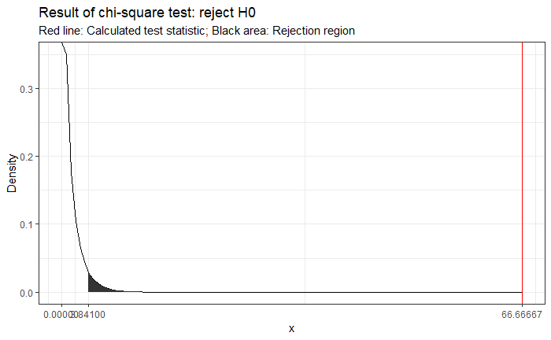

We could also compute the p-value using the `pchisq()` function, which tells us the probability of the observed cell frequencies if the null hypothesis was true (i.e., there was no association):

```r
p_val <- 1-pchisq(chisq_cal,df)
p_val
```

```
[1] 0.0000000000000003330669
```

The test statistic can also be calculated in R directly on the contingency table with the function `chisq.test()`.

```r
chisq.test(contigency_table, correct = FALSE)
```

```
    Pearson's Chi-squared test

data:  contigency_table
X-squared = 66.667, df = 1, p-value = 0.0000000000000003215
```

Since the p-value is smaller than 0.05 (i.e., the calculated test statistic is larger than the critical value), we reject H<sub>0</sub> that the two variables are independent.

```r
chisq.test(cont_table/10, correct = FALSE)
```

```
    Pearson's Chi-squared test

data:  cont_table/10
X-squared = 6.6667, df = 1, p-value = 0.009823
```

$$\phi=\sqrt{\frac{\chi^2}{n}}$$

The following guidelines are used to determine the magnitude of the effect size (Cohen, 1988):

- 0.1 (small effect)
- 0.3 (medium effect)
- 0.5 (large effect)

In our example, we can compute the effect sizes for the large and small samples as follows:

```r
test_stat <- chisq.test(cont_table, correct = FALSE)$statistic
phi1 <- sqrt(test_stat/n)
test_stat <- chisq.test(cont_table/10, correct = FALSE)$statistic
phi2 <- sqrt(test_stat/(n/10))
phi1
```

```
X-squared
0.3333333
```

```r
phi2
```

```
X-squared
0.3333333
```

You can see that the statistic is insensitive to the sample size.

Note that the Φ coefficient is appropriate for two dichotomous variables (resulting from a 2 x 2 table as above). If any your nominal variables has more than two categories, Cramér’s V should be used instead:

$$V=\sqrt{\frac{\chi^2}{n*df_{min}}}$$

where $df_{min}$ refers to the degrees of freedom associated with the variable that has fewer categories (e.g., if we have two nominal variables with 3 and 4 categories, $df_{min}$ would be 3 - 1 = 2). The degrees of freedom need to be taken into account when judging the magnitude of the effect sizes (see e.g., [here](http://www.real-statistics.com/chi-square-and-f-distributions/effect-size-chi-square/)).

Note that the `correct = FALSE` argument above ensures that the test statistic is computed in the same way as we have done by hand above. By default, `chisq.test()` applies a correction to prevent overestimation of statistical significance for small data (called the Yates’ correction). The correction is implemented by subtracting the value 0.5 from the computed difference between the observed and expected cell counts in the numerator of the test statistic. This means that the calculated test statistic will be smaller (i.e., more conservative). Although the adjustment may go too far in some instances, you should generally rely on the adjusted results, which can be computed as follows:

```r
chisq.test(contigency_table)
```

[output not shown]

As you can see, the results don’t change much in our example, since the differences between the observed and expected cell frequencies are fairly large relative to the correction.

Caution is warranted when the cell counts in the contingency table are small. The usual rule of thumb is that all cell counts should be at least 5 (this may be a little too stringent though). When some cell counts are too small, you can use Fisher’s exact test using the `fisher.test()` function.

```r
fisher.test(contigency_table)
```

[output not shown]

The Fisher test, while more conservative, also shows a significant difference between the proportions (p < 0.05). This is not surprising since the cell counts in our example are fairly large.

### Sample size

To **calculate the required sample size** when comparing proportions, the `power.prop.test()` function can be used. For example, we could ask how large our sample needs to be if we would like to compare two groups with conversion rates of 2% and 2.5%, respectively using the conventional settings for $\alpha$ and $\beta$:

```r
power.prop.test(p1=0.02,p2=0.025,sig.level=0.05,power=0.8)
```

```
     Two-sample comparison of proportions power calculation

              n = 13808.92
             p1 = 0.02
             p2 = 0.025
      sig.level = 0.05
          power = 0.8
    alternative = two.sided

NOTE: n is number in *each* group
```

The output tells us that we need 13809 observations per group to detect a difference of the desired size.